# NACHO

## 3.5 The `autoplot()` function

The `autoplot()` function provides an easy way to plot any quality-control from the `visualise()` function.

```r
autoplot(
  object = GSE74821,
  x = "BD",
  colour = "CartridgeID",
  size = 0.5,
  show_legend = TRUE
)
```

The possible metrics (`x`) are:

- `"BD"` (Binding Density)
- `"FoV"` (Imaging)
- `"PCL"` (Positive Control Linearity)
- `"LoD"` (Limit of Detection)
- `"Positive"` (Positive Controls)
- `"Negative"` (Negative Controls)
- `"Housekeeping"` (Housekeeping Genes)
- `"PN"` (Positive Controls vs. Negative Controls)
- `"ACBD"` (Average Counts vs. Binding Density)
- `"ACMC"` (Average Counts vs. Median Counts)
- `"PCA12"` (Principal Component 1 vs. 2)
- `"PCAi"` (Principal Component scree plot)
- `"PCA"` (Principal Components planes)
- `"PFNF"` (Positive Factor vs. Negative Factor)
- `"HF"` (Housekeeping Factor)
- `"NORM"` (Normalisation Factor)

### 3.5.1 Binding Density

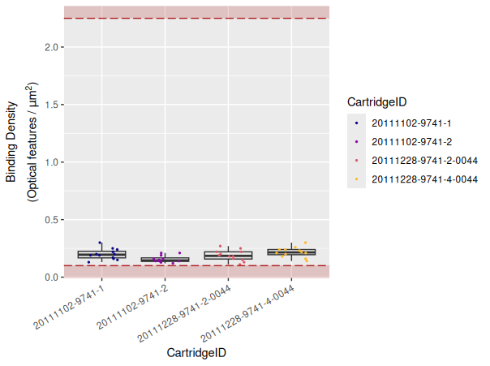

### 3.5.2 Imaging

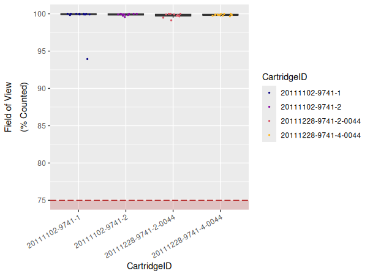

### 3.5.3 Positive Control Linearity

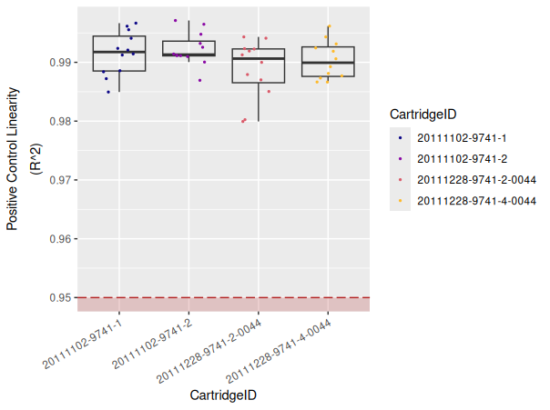

### 3.5.4 Limit of Detection

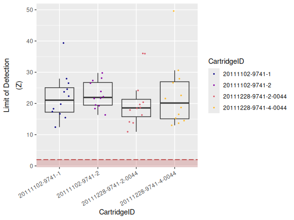

### 3.5.5 Positive Controls

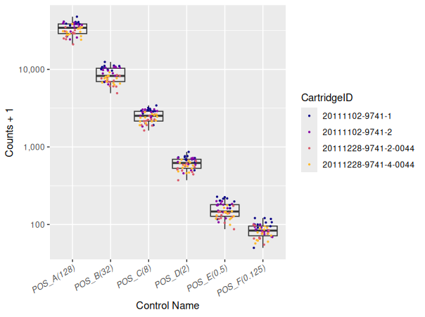

### 3.5.6 Negative Controls

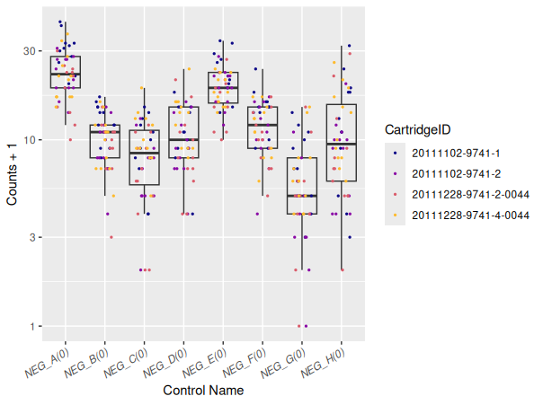

### 3.5.7 Housekeeping Genes

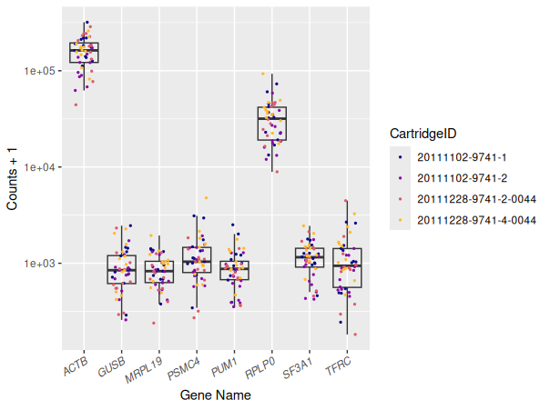

### 3.5.8 Positive Controls vs. Negative Controls

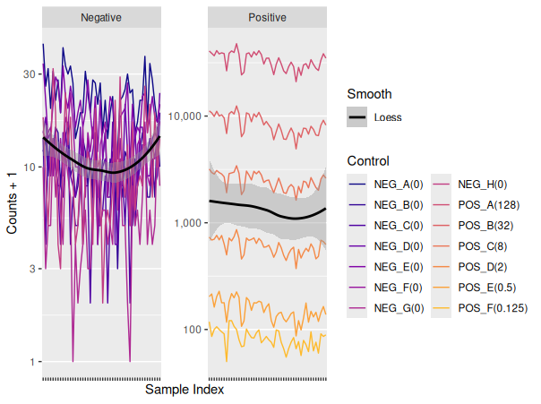

### 3.5.9 Average Counts vs. Binding Density

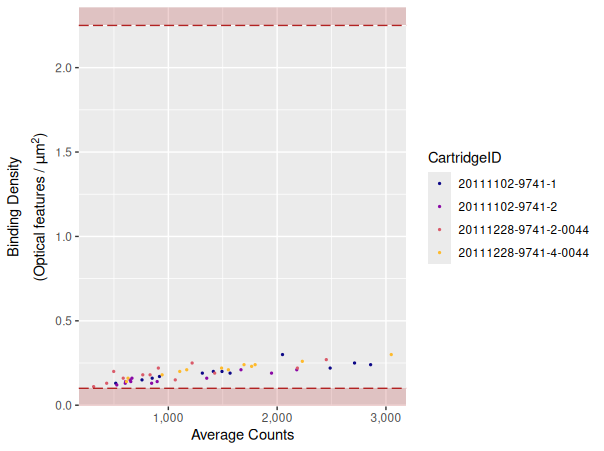

### 3.5.10 Average Counts vs. Median Counts

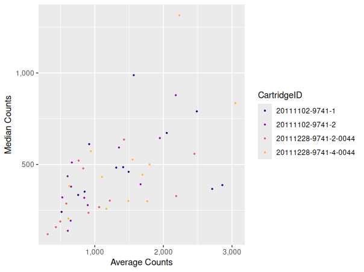

### 3.5.11 Principal Component 1 vs. 2

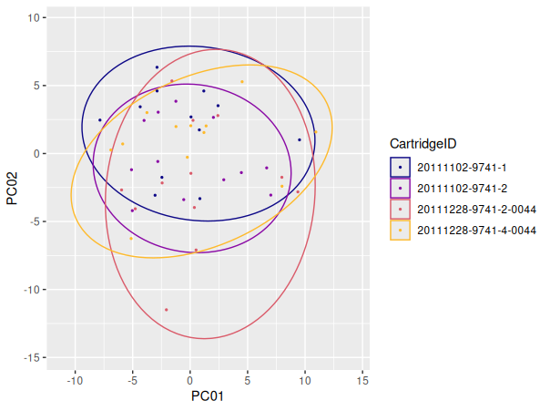

### 3.5.12 Principal Component scree plot

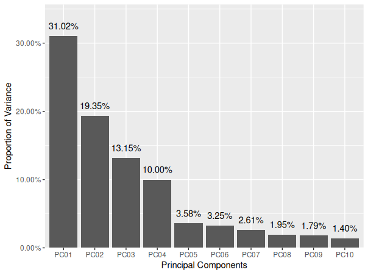

### 3.5.13 Principal Components planes

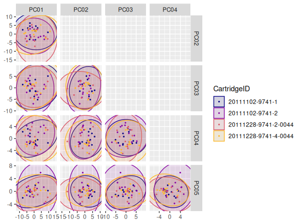

### 3.5.14 Positive Factor vs. Negative Factor

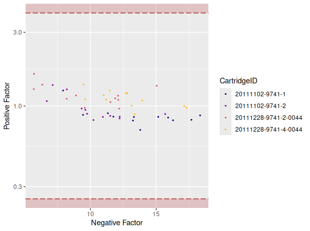

### 3.5.15 Housekeeping Factor

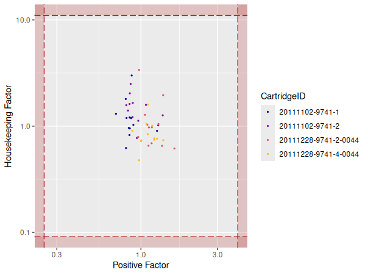

### 3.5.16 Normalisation Factor

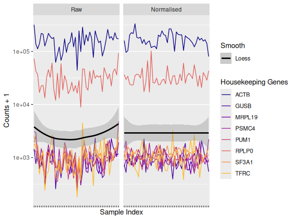

## 3.6 NACHO as a standalone app

*NACHO* is also available as a standalone app to be used in a Shiny Server configuration. A convenience function `deploy()` is available to directly copy the *NACHO* app to the default directory of a Shiny Server.

```r
deploy(directory = "/srv/shiny-server", app_name = "NACHO")
```

The app can also be run directly, without manually summarising and normalising RCC files:

[figure not shown]

```r
shiny::runApp(system.file("app", package = "NACHO"))
```

## 3.7 The `render()` function

The `render()` function renders a comprehensive HTML report, using `print(..., echo = TRUE)`, which includes all quality-control metrics and description of those metrics.

```r
render(
  nacho_object = GSE74821,
  colour = "CartridgeID",
  output_file = "NACHO_QC.html",
  output_dir = ".",
  size = 0.5,
  show_legend = TRUE,
  clean = TRUE
)
```

The underneath function `print()` can be used directly within any R Markdown chunk, setting the parameter `echo = TRUE`.

```r
print(
  x = GSE74821,
  colour = "CartridgeID",
  size = 0.5,
  show_legend = TRUE,
  echo = TRUE,
  title_level = 3
)
```

### 3.7.1 RCC Summary

- Samples: 48
- Endogenous: 50
- Housekeeping: 8
- Negative: 8
- Positive: 6

### 3.7.2 Settings

- Predict housekeeping genes: FALSE
- Normalise using housekeeping genes: TRUE
- Housekeeping genes available: MRPL19, PSMC4, SF3A1, RPLP0, PUM1, ACTB, TFRC and GUSB
- Normalise using: GLM
- Principal components to compute: 10
- Remove outliers: FALSE
  - Binding Density (BD) < 0.1
  - Binding Density (BD) > 2.25
  - Field of View (FoV) < 75
  - Positive Control Linearity (PCL) < 0.95
  - Limit of Detection (LoD) < 2
  - Positive normalisation factor (Positive_factor) < 0.25
  - Positive normalisation factor (Positive_factor) > 4
  - Housekeeping normalisation factor (house_factor) < 0.091
  - Housekeeping normalisation factor (house_factor) > 11

### 3.7.3 QC Metrics

#### 3.7.3.1 Binding Density

The imaging unit only counts the codes that are unambiguously distinguishable.  
It simply will not count codes that overlap within an image.  
This provides increased confidence that the molecular counts you receive are from truly recognisable codes.  
Under most conditions, forgoing the few barcodes that do overlap will not impact your data.  
Too many overlapping codes in the image, however, will create a condition called image saturation in which significant data loss could occur (critical data loss from saturation is uncommon).

To determine the level of image saturation, the nCounter instrument calculates the number of optical features per square micron for each lane as it processes the images.  
This is called the **Binding Density** (**BD**).  
The **Binding Density** is useful for determining whether data collection has been compromised due to image saturation. The acceptable range for **Binding Density** is:

- `0.1 - 2.25` for **MAX**/**FLEX** instruments
- `0.1 - 1.8` for **SPRINT** instruments

Within these ranges, relatively few reporters on the slide surface will overlap, enabling the instrument to accurately tabulate counts for each reporter species.  
A **Binding Density** significantly greater than the upper limit in either range is indicative of overlapping reporters on the slide surface.  
The counts observed in lanes with a **Binding Density** at this level may have had significant numbers of codes ignored, which could potentially affect quantification and linearity of the assay.

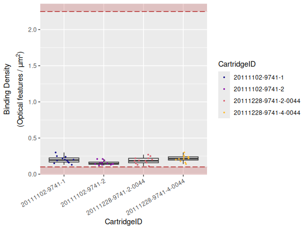

#### 3.7.3.2 Field of View (Imaging)

Each individual lane scanned on an nCounter system is divided into a few hundred imaging sections, called Fields of View (**FOV**), the exact number of which will depend on the system being used (*i.e.*, **MAX/FLEX** or **SPRINT**), and the scanner settings selected by the user.  
The system images these **FOV**s separately, and sums the barcode counts of all **FOV**s from a single lane to form the final raw data count for each unique barcode target.  
Finally, the system reports the number of **FOV**s successfully imaged as **FOV** Counted.

Significant discrepancy between the number of **FOV** for which imaging was attempted (**FOV Count**) and for which imaging was successful (**FOV Counted**) may indicate an issue with imaging performance.  
Recommended percentage of registered FOVs (*i.e.*, **FOV Counted** over **FOV Count**) is `75 %`.

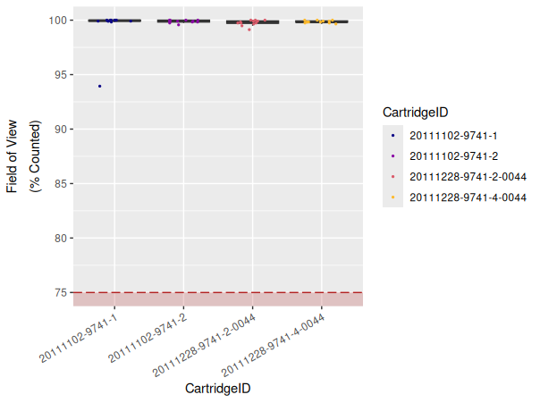

#### 3.7.3.3 Positive Control Linearity

Six synthetic DNA control targets are included with every nCounter Gene Expression assay.  
Their concentrations range linearly (in *codeset*) from `128 fM` to `0.125 fM`, and they are referred to as **POS_A** to **POS_F**, respectively.  
These **Positive Controls** are typically used to measure the efficiency of the hybridization reaction, and their step-wise concentrations also make them useful in checking the linearity performance of the assay.

Since the known concentrations of the **Positive Controls** increase in a linear fashion, the resulting counts should, as well.

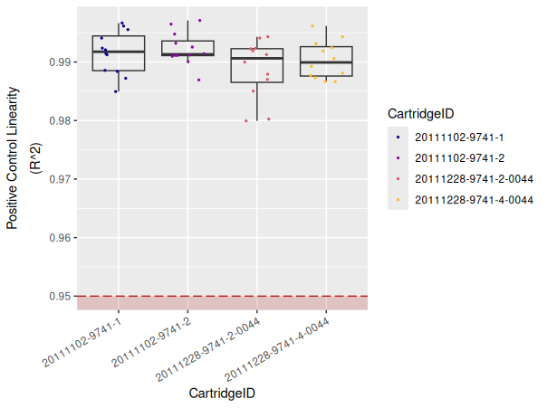

#### 3.7.3.4 Limit of Detection

The limit of detection (**LoD**) is determined by measuring the ability to detect **POS_E**, the `0.5 fM` positive control probe, which corresponds to about 10,000 copies of this target within each sample tube.  
On a **FLEX**/**MAX** system, the standard input of `100 ng` of total RNA will roughly correspond to about 10,000 cell equivalents (assuming one cell contains `10 pg` total RNA on average).  
An nCounter assay run on the **FLEX**/**MAX** system should thus conservatively be able to detect roughly one transcript copy per cell for each target (or 10,000 total transcript copies).  
In most (codeset) assays, you will observe that even the **POS_F** probe (equivalent to 0.25 copies per cell) is detectable above background.

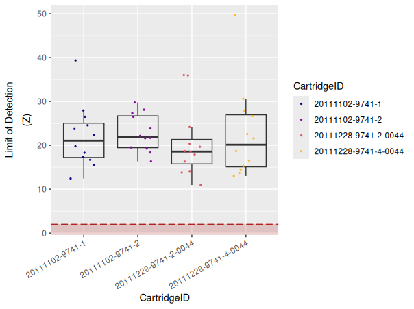

### 3.7.4 Control Genes

#### 3.7.4.1 Positive

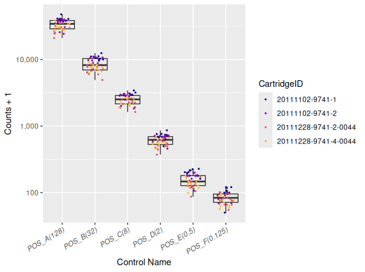

#### 3.7.4.2 Negative

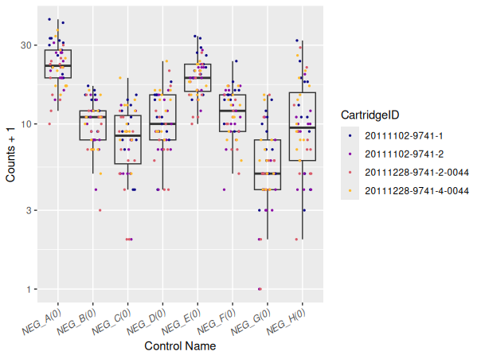

#### 3.7.4.3 Housekeeping

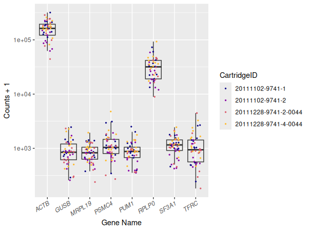

#### 3.7.4.4 Control Probe Expression

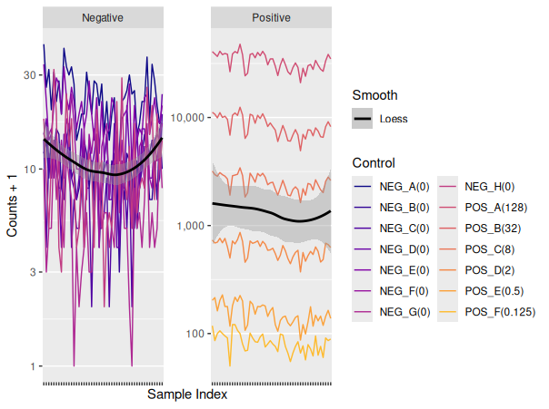

### 3.7.5 Quality-Control Visuals

#### 3.7.5.1 Average Count vs. Binding Density

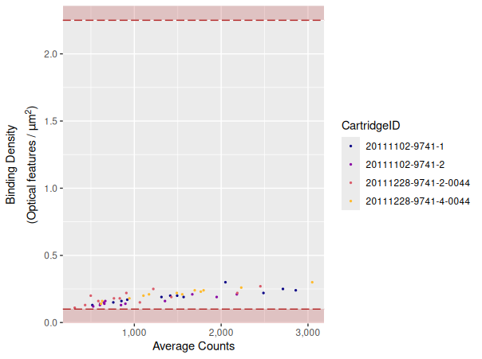

#### 3.7.5.2 Average Count vs. Median Count

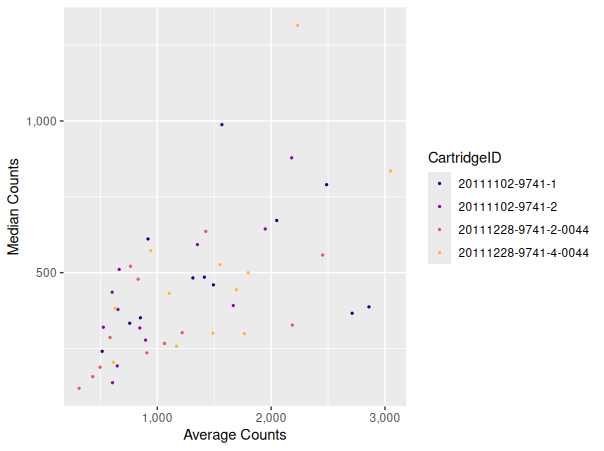